# Final Project by Wonjun Lee

```
##  [1] "ListingKey"
##  [2] "ListingNumber"
##  [3] "ListingCreationDate"
##  [4] "CreditGrade"
##  [5] "Term"
##  [6] "LoanStatus"
##  [7] "ClosedDate"
##  [8] "BorrowerAPR"
##  [9] "BorrowerRate"
## [10] "LenderYield"
## [11] "EstimatedEffectiveYield"
## [12] "EstimatedLoss"
## [13] "EstimatedReturn"
## [14] "ProsperRating..numeric."
## [15] "ProsperRating..Alpha."
```

[output cut: 66 more lines]

# Univariate Plots Section

```
## [1] 113937     81
```

```
##                    ListingKey     ListingNumber
##  17A93590655669644DB4C06:     6   Min.   :      4
##  349D3587495831350F0F648:     4   1st Qu.: 400919
##  47C1359638497431975670B:     4   Median : 600554
##  8474358854651984137201C:     4   Mean   : 627886
##  DE8535960513435199406CE:     4   3rd Qu.: 892634
##  04C13599434217079754AEE:     3   Max.   :1255725
##  (Other)                :113912
##                     ListingCreationDate  CreditGrade         Term
##  2013-10-02 17:20:16.550000000:     6          :84984   Min.   :12.00
##  2013-08-28 20:31:41.107000000:     4   C      : 5649   1st Qu.:36.00
##  2013-09-08 09:27:44.853000000:     4   D      : 5153   Median :36.00
##  2013-12-06 05:43:13.830000000:     4   B      : 4389   Mean   :40.83
##  2013-12-06 11:44:58.283000000:     4   AA     : 3509   3rd Qu.:36.00
##  2013-08-21 07:25:22.360000000:     3   HR     : 3508   Max.   :60.00
##  (Other)                      :113912   (Other): 6745
##                  LoanStatus                  ClosedDate
##  Current              :56576                      :58848
##  Completed            :38074   2014-03-04 00:00:00:  105
##  Chargedoff           :11992   2014-02-19 00:00:00:  100
##  Defaulted            : 5018   2014-02-11 00:00:00:   92
##  Past Due (1-15 days) :  806   2012-10-30 00:00:00:   81
##  Past Due (31-60 days):  363   2013-02-26 00:00:00:   78
##  (Other)              : 1108   (Other)            :54633
##   BorrowerAPR       BorrowerRate     LenderYield
##  Min.   :0.00653   Min.   :0.0000   Min.   :-0.0100
##  1st Qu.:0.15629   1st Qu.:0.1340   1st Qu.: 0.1242
##  Median :0.20976   Median :0.1840   Median : 0.1730
##  Mean   :0.21883   Mean   :0.1928   Mean   : 0.1827
##  3rd Qu.:0.28381   3rd Qu.:0.2500   3rd Qu.: 0.2400
##  Max.   :0.51229   Max.   :0.4975   Max.   : 0.4925
##  NA's   :25
##  EstimatedEffectiveYield EstimatedLoss   EstimatedReturn
##  Min.   :-0.183          Min.   :0.005   Min.   :-0.183
##  1st Qu.: 0.116          1st Qu.:0.042   1st Qu.: 0.074
##  Median : 0.162          Median :0.072   Median : 0.092
##  Mean   : 0.169          Mean   :0.080   Mean   : 0.096
##  3rd Qu.: 0.224          3rd Qu.:0.112   3rd Qu.: 0.117
##  Max.   : 0.320          Max.   :0.366   Max.   : 0.284
##  NA's   :29084           NA's   :29084   NA's   :29084
```

[output cut: 193 more lines]

```
##  Min.   :    0.00                Min.   :0.7000   Min.   : 0.00000
##  1st Qu.:    0.00                1st Qu.:1.0000   1st Qu.: 0.00000
##  Median :    0.00                Median :1.0000   Median : 0.00000
##  Mean   :   25.14                Mean   :0.9986   Mean   : 0.04803
##  3rd Qu.:    0.00                3rd Qu.:1.0000   3rd Qu.: 0.00000
##  Max.   :21117.90                Max.   :1.0125   Max.   :39.00000
##
##  InvestmentFromFriendsCount InvestmentFromFriendsAmount   Investors
##  Min.   : 0.00000           Min.   :    0.00            Min.   :   1.00
##  1st Qu.: 0.00000           1st Qu.:    0.00            1st Qu.:   2.00
##  Median : 0.00000           Median :    0.00            Median :  44.00
##  Mean   : 0.02346           Mean   :   16.55            Mean   :  80.48
##  3rd Qu.: 0.00000           3rd Qu.:    0.00            3rd Qu.: 115.00
##  Max.   :33.00000           Max.   :25000.00            Max.   :1189.00
##
```

```
## 'data.frame':    113937 obs. of  81 variables:
##  $ ListingKey                         : Factor w/ 113066 levels "00003546482094282EF90E5",..: 7180 7193 6647 6669 6686 6689 6699 6706 6687 6687 ...
##  $ ListingNumber                      : int  193129 1209647 81716 658116 909464 1074836 750899 768193 1023355 1023355 ...
##  $ ListingCreationDate                : Factor w/ 113064 levels "2005-11-09 20:44:28.847000000",..: 14184 111894 6429 64760 85967 100310 72556 74019 97834 97834 ...
##  $ CreditGrade                        : Factor w/ 9 levels "","A","AA","B",..: 5 1 8 1 1 1 1 1 1 1 ...
##  $ Term                               : int  36 36 36 36 36 60 36 36 36 36 ...
##  $ LoanStatus                         : Factor w/ 12 levels "Cancelled","Chargedoff",..: 3 4 3 4 4 4 4 4 4 4 ...
##  $ ClosedDate                         : Factor w/ 2803 levels "","2005-11-25 00:00:00",..: 1138 1 1263 1 1 1 1 1 1 1 ...
##  $ BorrowerAPR                        : num  0.165 0.12 0.283 0.125 0.246 ...
##  $ BorrowerRate                       : num  0.158 0.092 0.275 0.0974 0.2085 ...
##  $ LenderYield                        : num  0.138 0.082 0.24 0.0874 0.1985 ...
##  $ EstimatedEffectiveYield            : num  NA 0.0796 NA 0.0849 0.1832 ...
##  $ EstimatedLoss                      : num  NA 0.0249 NA 0.0249 0.0925 ...
##  $ EstimatedReturn                    : num  NA 0.0547 NA 0.06 0.0907 ...
##  $ ProsperRating..numeric.            : int  NA 6 NA 6 3 5 2 4 7 7 ...
```

[output cut: 67 more lines]

There are 81 variables with 113937 observations. Plotting a histogram for each variable will be helpful in understanding the data set. I will only use variables that are not factors.

### Finding good variables

```r
library(dplyr)
colSums(is.na(df))
```

```
##                          ListingKey                       ListingNumber
##                                   0                                   0
##                 ListingCreationDate                         CreditGrade
##                                   0                                   0
##                                Term                          LoanStatus
##                                   0                                   0
##                          ClosedDate                         BorrowerAPR
##                                   0                                  25
##                        BorrowerRate                         LenderYield
##                                   0                                   0
##             EstimatedEffectiveYield                       EstimatedLoss
##                               29084                               29084
##                     EstimatedReturn             ProsperRating..numeric.
##                               29084                               29084
##               ProsperRating..Alpha.                        ProsperScore
##                                   0                               29084
##           ListingCategory..numeric.                       BorrowerState
##                                   0                                   0
##                          Occupation                    EmploymentStatus
##                                   0                                   0
##            EmploymentStatusDuration                 IsBorrowerHomeowner
##                                7625                                   0
##                    CurrentlyInGroup                            GroupKey
##                                   0                                   0
##                    DateCreditPulled               CreditScoreRangeLower
##                                   0                                 591
##               CreditScoreRangeUpper             FirstRecordedCreditLine
##                                 591                                   0
##                  CurrentCreditLines                     OpenCreditLines
##                                7604                                7604
##          TotalCreditLinespast7years               OpenRevolvingAccounts
##                                 697                                   0
##         OpenRevolvingMonthlyPayment                InquiriesLast6Months
##                                   0                                 697
##                      TotalInquiries                CurrentDelinquencies
##                                1159                                 697
##                    AmountDelinquent             DelinquenciesLast7Years
##                                7622                                 990
##            PublicRecordsLast10Years           PublicRecordsLast12Months
##                                 697                                7604
```

[output cut: 27 more lines]

```
##                                   0                                   0
##                 LP_CustomerPayments        LP_CustomerPrincipalPayments
##                                   0                                   0
##                  LP_InterestandFees                      LP_ServiceFees
##                                   0                                   0
##                   LP_CollectionFees               LP_GrossPrincipalLoss
##                                   0                                   0
##                 LP_NetPrincipalLoss     LP_NonPrincipalRecoverypayments
##                                   0                                   0
##                       PercentFunded                     Recommendations
##                                   0                                   0
##          InvestmentFromFriendsCount         InvestmentFromFriendsAmount
##                                   0                                   0
##                           Investors
##                                   0
```

This will help me filter out variables with too many NA’s.

### Term

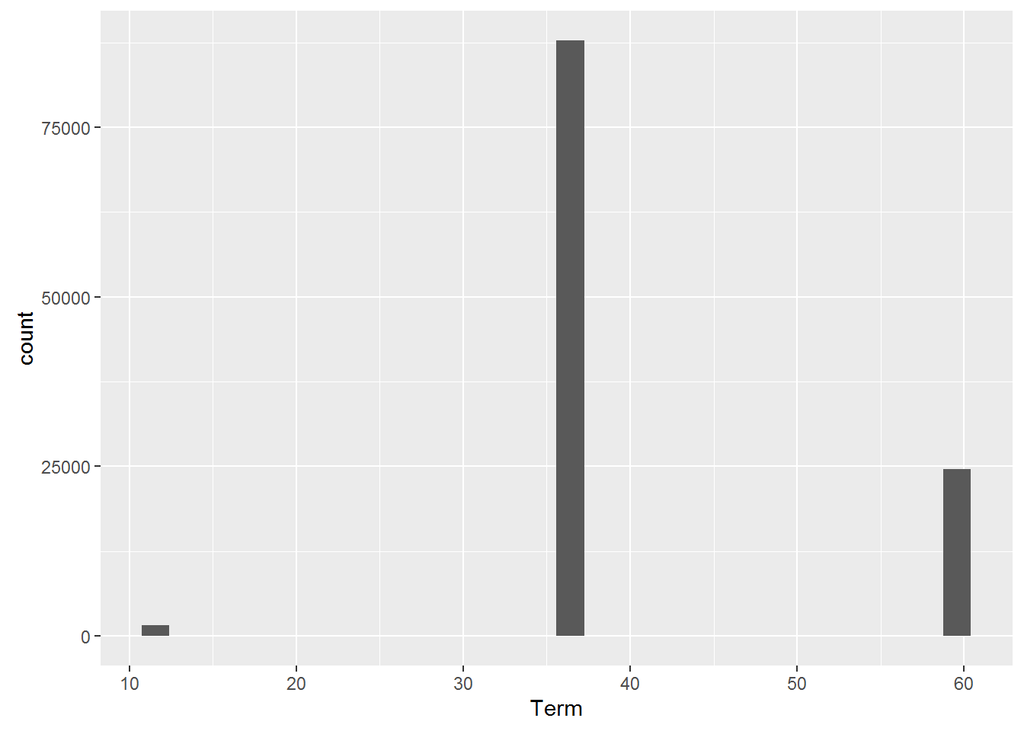

```r
ggplot(aes(x=Term), data=df) +
  geom_histogram(bins=30)
```

There are only 3 terms people use. More specifically,

```r
table(df$Term)
```

```
##
##    12    36    60
##  1614 87778 24545
```

```r
df$Term <- factor(df$Term)
```

12, 36 and 60. Term will be used as a factored variable.

### Borrower Rate, Borrower APR, Lender Yield, EstimatedEffectiveYield

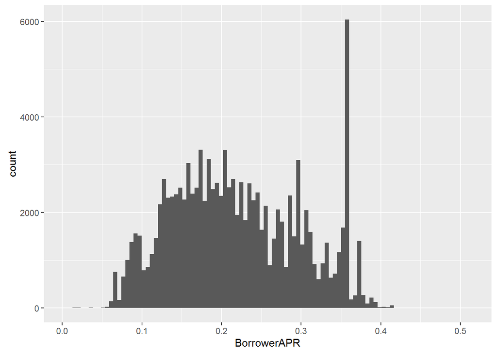

```r
ggplot(aes(x=BorrowerAPR), data=df) +
  geom_histogram(bins=100)
```

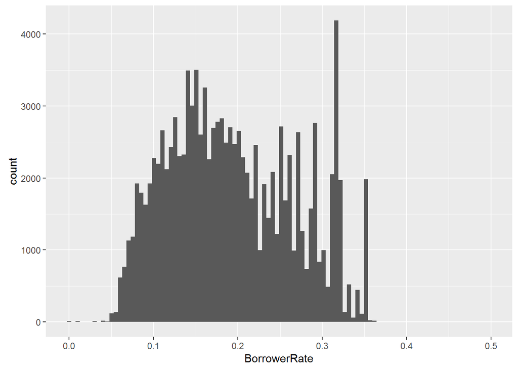

```r
ggplot(aes(x=BorrowerRate), data=df) +
  geom_histogram(bins=100)
```

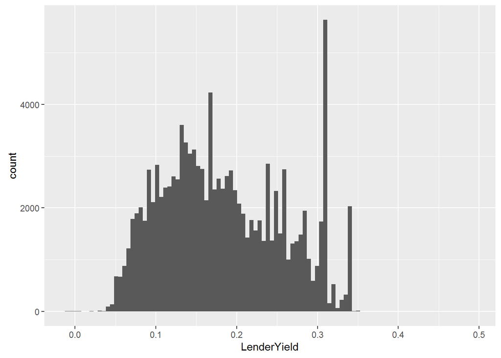

```r
ggplot(aes(x=LenderYield), data=df) +
  geom_histogram(bins=100)
```

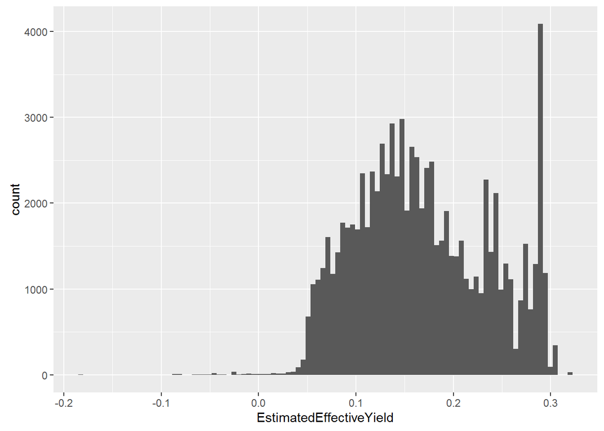

```r
ggplot(aes(x=EstimatedEffectiveYield), data=df) +
  geom_histogram(bins=100)
```

The graphs are similar to each other. Right skewed graph with an abnormal peak at the right. I will only use Borrower Rate for convenience.

### Borrower Rate

```r
df %>%
  group_by(BorrowerRate) %>%
  summarise(Count=n()) %>%
  arrange(desc(Count))
```

```
## Source: local data frame [2,294 x 2]
##
##    BorrowerRate Count
##           (dbl) (int)
## 1        0.3177  3672
## 2        0.3500  1905
## 3        0.3199  1651
## 4        0.2900  1508
## 5        0.2699  1319
## 6        0.1500  1182
## 7        0.1400  1035
## 8        0.1099   949
## 9        0.2000   907
## 10       0.1585   806
## ..          ...   ...
```

```r
df$BorrowerAPR.bucket <- cut(df$BorrowerAPR,breaks=10)
table(df$BorrowerAPR.bucket)
```

```
##
## (0.00602,0.0571]   (0.0571,0.108]    (0.108,0.158]    (0.158,0.209]
##               70             8501            21072            27021
##    (0.209,0.259]     (0.259,0.31]     (0.31,0.361]    (0.361,0.411]
##            21734            17373            15481             2598
##    (0.411,0.462]    (0.462,0.513]
##               58                4
```

### Estimated Return

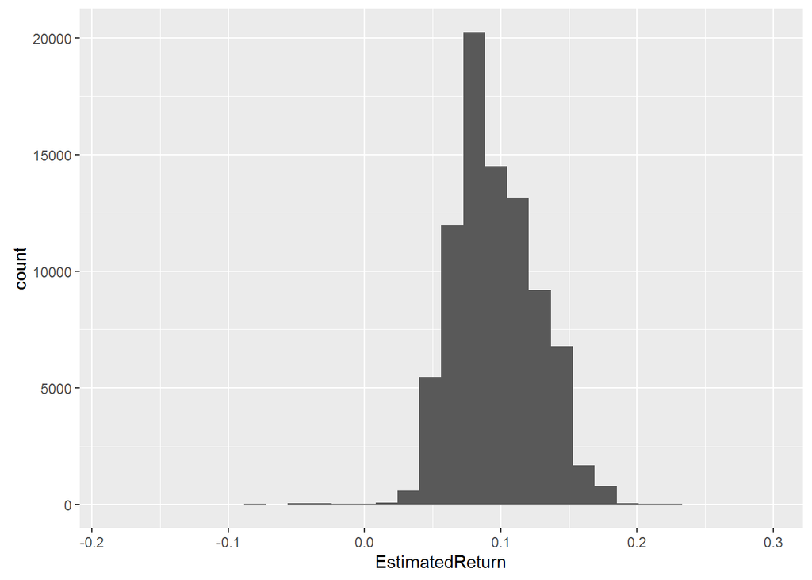

```r
ggplot(aes(x=EstimatedReturn), data=df) +
  geom_histogram(bins=30)
```

This looks a right skewed graph with outliers less than 0.0.

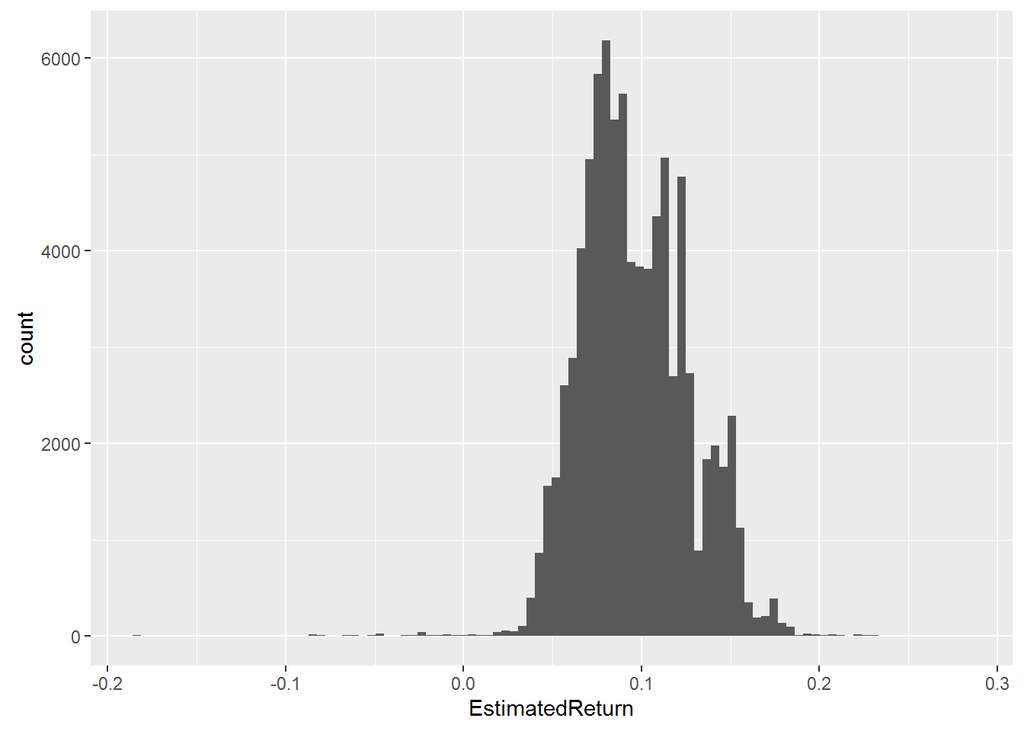

```r
ggplot(aes(x=EstimatedReturn), data=df) +
  geom_histogram(bins=100)
```

The graph with more bins shows clear outliers with negative values and more than 0.2.

```r
summary(df$EstimatedReturn)
```

```
##    Min. 1st Qu.  Median    Mean 3rd Qu.    Max.    NA's
##  -0.183   0.074   0.092   0.096   0.117   0.284   29084
```

```r
df$EstimatedReturn.bucket <- cut(df$EstimatedReturn, c(-0.1,0,0.2,0.3))
table(df$EstimatedReturn.bucket)
```

```
##
##  (-0.1,0]   (0,0.2] (0.2,0.3]
##       176     84577        80
```

There are 176 observations less than 0.0 and 80 observations more than 0.2.

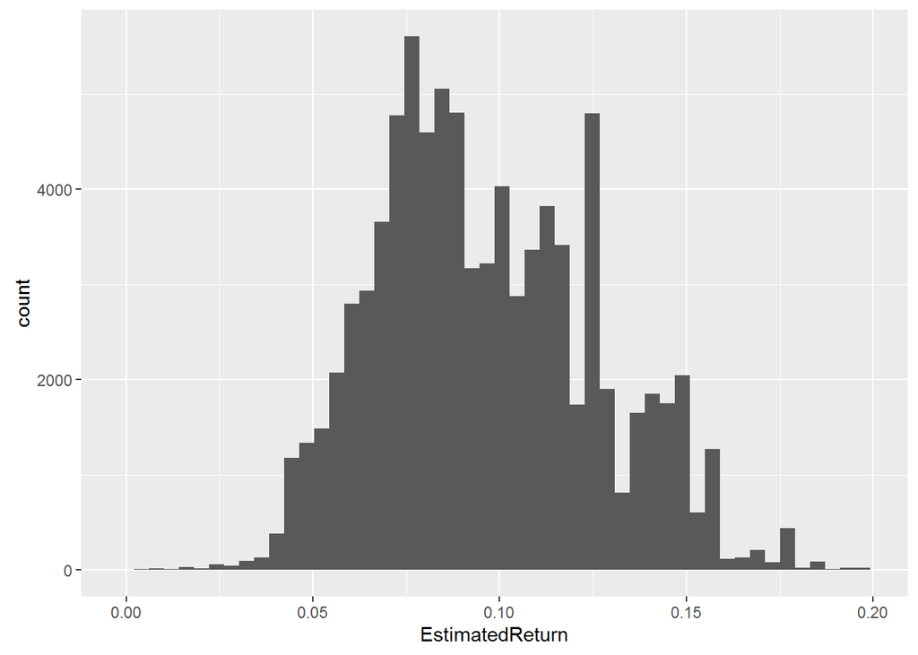

```r
ggplot(aes(x=EstimatedReturn), data=subset(df,df$EstimatedReturn>0 & df$EstimatedReturn<0.2)) +
  geom_histogram(bins=50)
```

```r
  scale_x_sqrt()
```

```
## <ScaleContinuousPosition>
##  Range:
##  Limits:    0 --    1
```

The graph is drawn after Estimated Return is filtered (more than 0 and less than 0.2). Similar to the previous variables, there is a peak at the right.

### Prosper Score

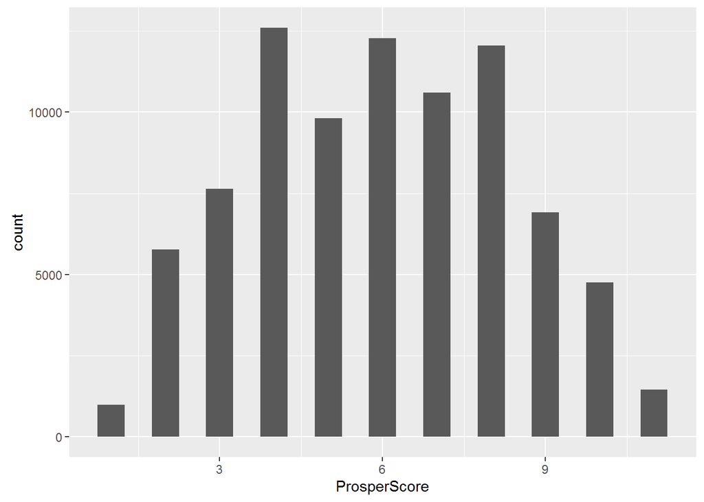

```r
ggplot(aes(x=ProsperScore
), data=df) +
  geom_histogram(binwidth=.5)
```

```r
table(df$ProsperScore)
```

```
##
##     1     2     3     4     5     6     7     8     9    10    11
##   992  5766  7642 12595  9813 12278 10597 12053  6911  4750  1456
```

Prosper score is ranging from 1 to 11.

```r
df$ProsperScore <- factor(df$ProsperScore)
```

Prosper score is factored.

### Employment Status Duration

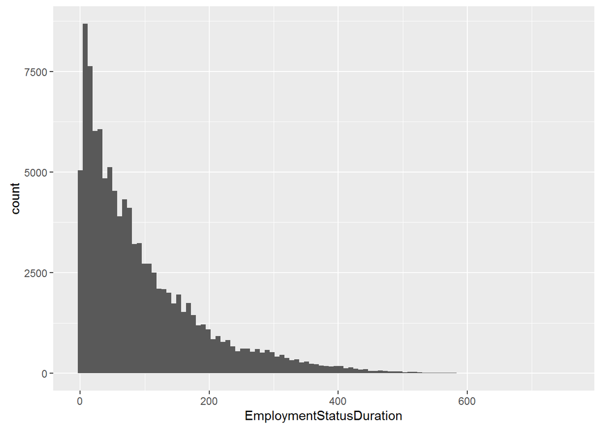

```r
ggplot(aes(x=EmploymentStatusDuration), data=df) +
  geom_histogram(bins=100)
```

This is very nice looking right skewed graph without a peak at the right.

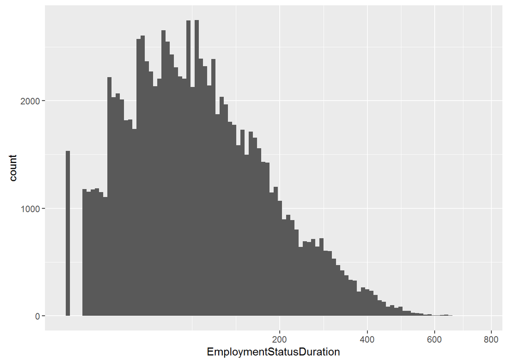

```r
ggplot(aes(x=EmploymentStatusDuration), data=df) +
  geom_histogram(bins=100) +
  scale_x_sqrt()
```

Square root is applied to see a clear right skewed shape.

### CreditScoreRangeLower and CreditScoreRangeUpper

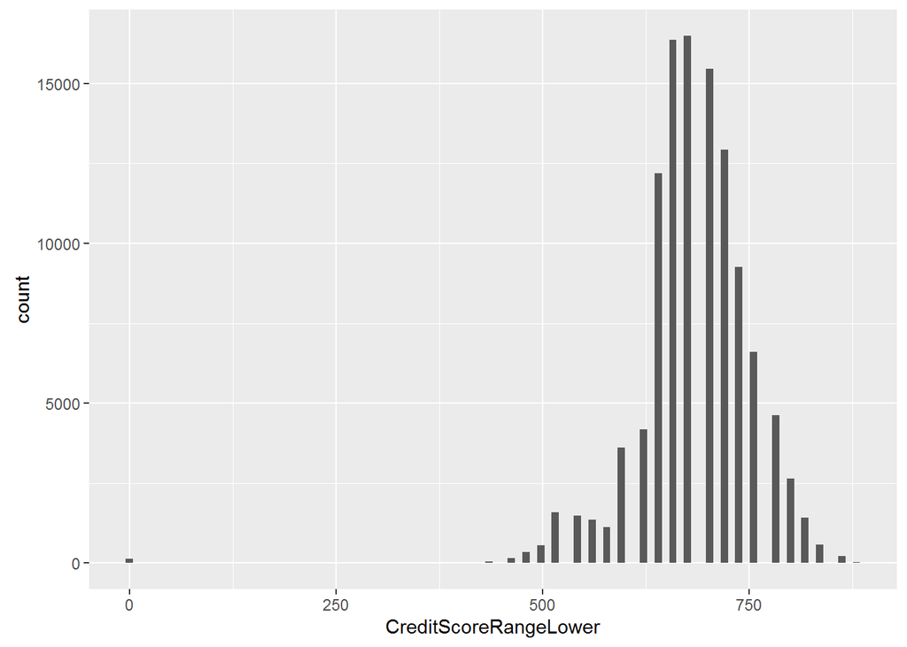

```r
ggplot(aes(x=CreditScoreRangeLower), data=df) +
  geom_histogram(bins=100)
```

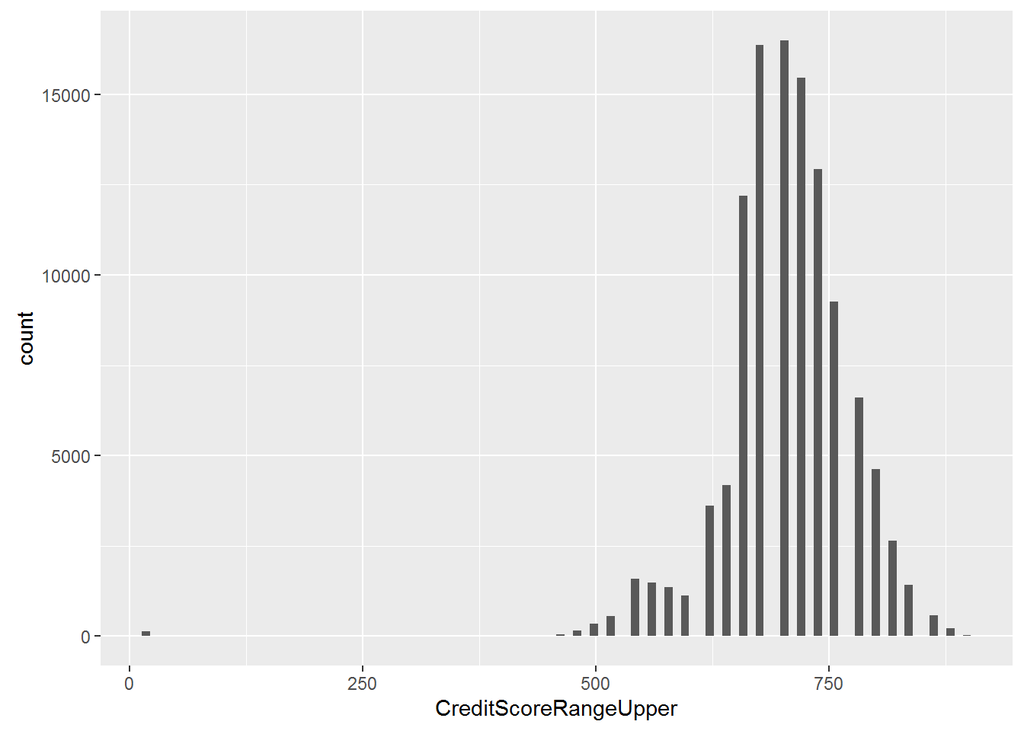

```r
ggplot(aes(x=CreditScoreRangeUpper), data=df) +
  geom_histogram(bins=100)
```

These two histograms are very similar. Instead of using these 2 variables, I will create a new variable ‘CreditScoreRangeMid’ that is the average of these 2.

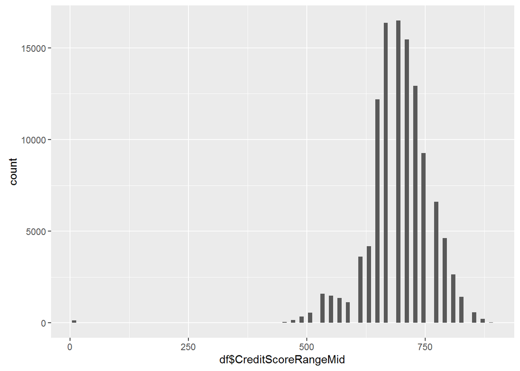

```r
# Creating a new variable
df$CreditScoreRangeMid <- (df$CreditScoreRangeLower + df$CreditScoreRangeUpper) /2

ggplot(aes(x=df$CreditScoreRangeMid), data=df) +
  geom_histogram(bins=100)
```

### CurrentCreditLines, OpenCreditLines, TotalCreditLinespast7years

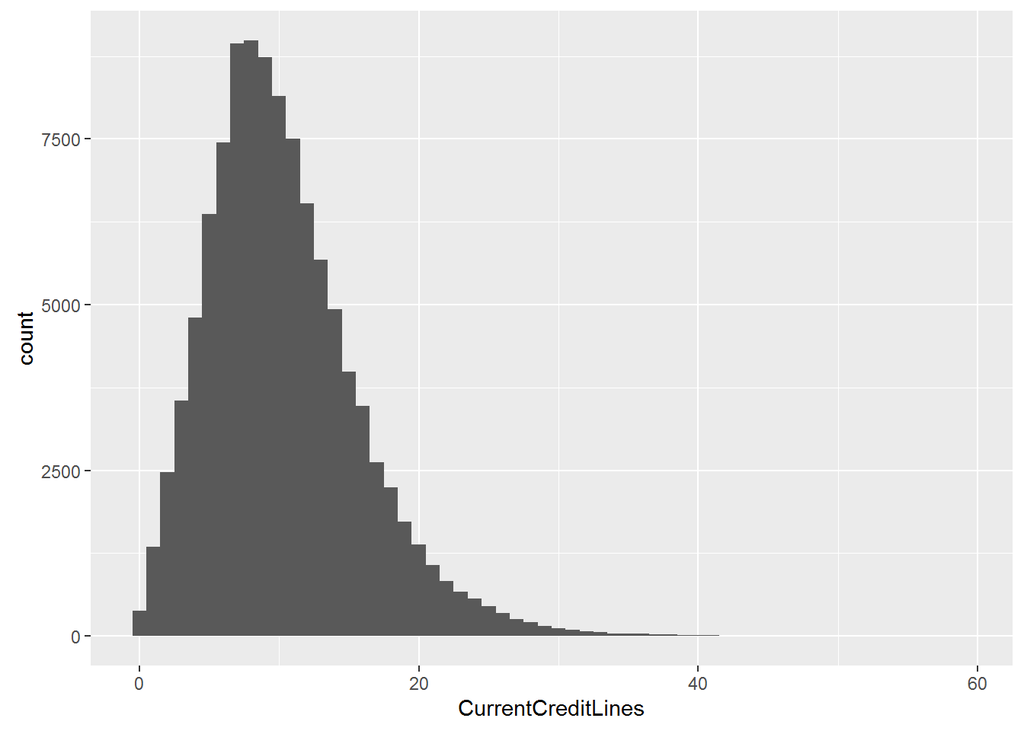

```r
ggplot(aes(x=CurrentCreditLines), data=df) +
  geom_histogram(binwidth=1)
```

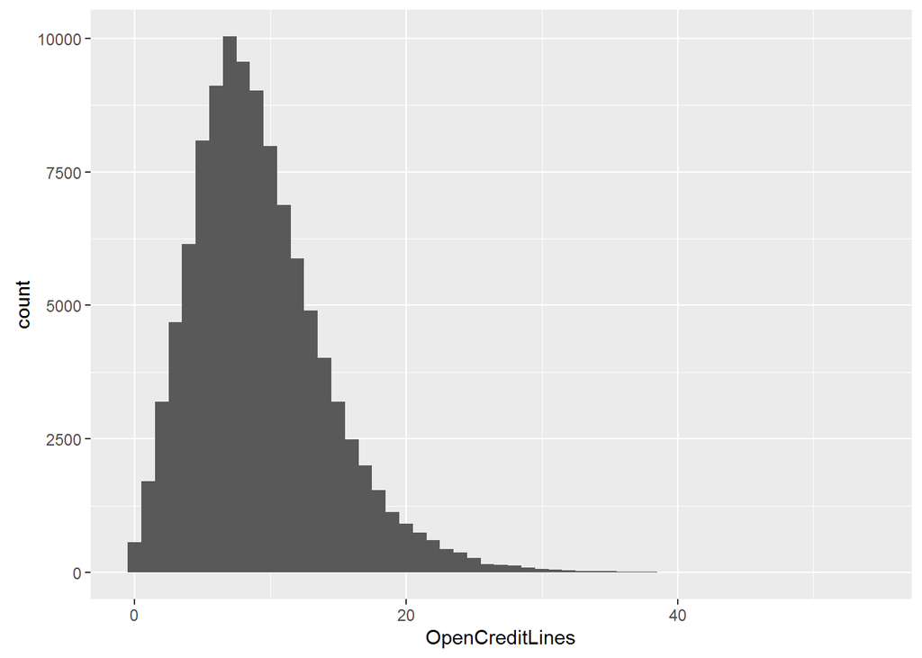

```r
ggplot(aes(x=OpenCreditLines), data=df) +
  geom_histogram(binwidth=1)
```

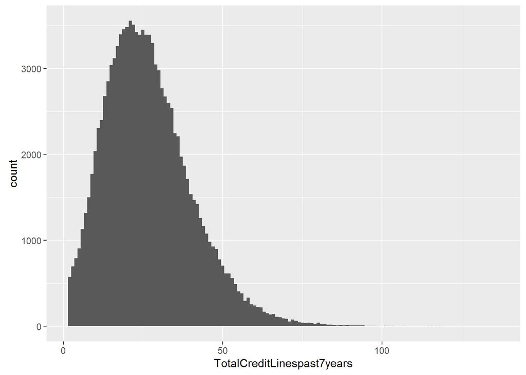

```r
ggplot(aes(x=TotalCreditLinespast7years), data=df) +
  geom_histogram(binwidth=1)
```

These are nice looking right skewed histograms.

### TotalTrades

```r
summary(df$TotalTrades)
```

```
##    Min. 1st Qu.  Median    Mean 3rd Qu.    Max.    NA's
##    0.00   15.00   22.00   23.23   30.00  126.00    7544
```

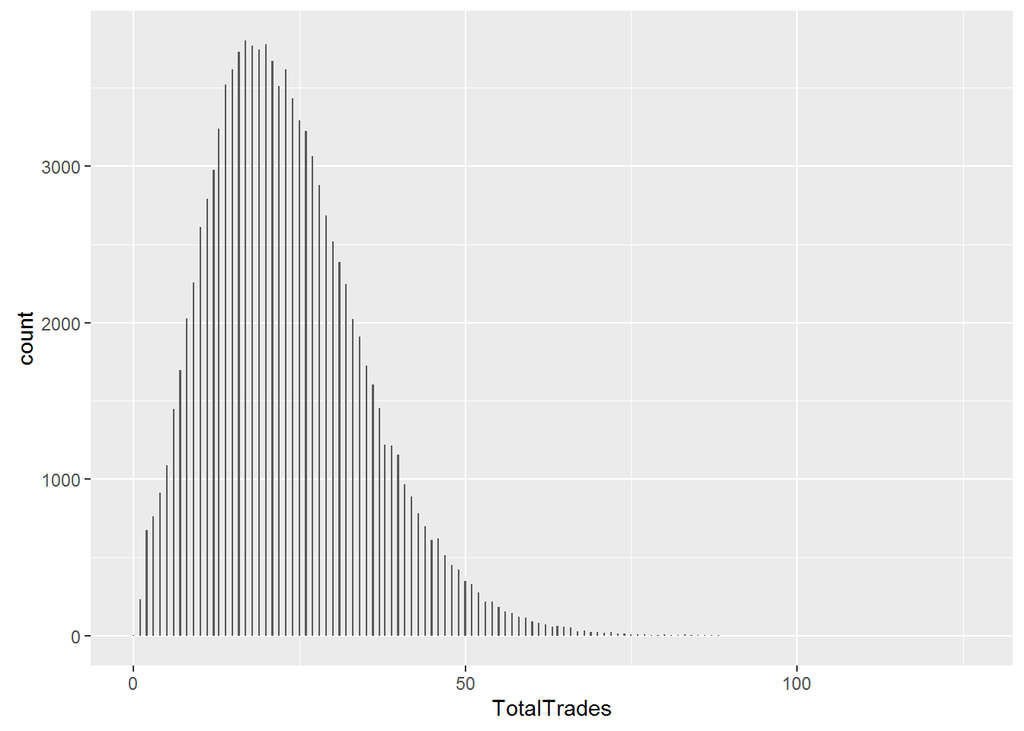

```r
ggplot(aes(x=TotalTrades), data=subset(df,!is.na(TotalTrades))) +
  geom_histogram(bins=500)
```

### DebtToIncomeRatio

```r
summary(df$DebtToIncomeRatio)
```

```
##    Min. 1st Qu.  Median    Mean 3rd Qu.    Max.    NA's
##   0.000   0.140   0.220   0.276   0.320  10.010    8554
```

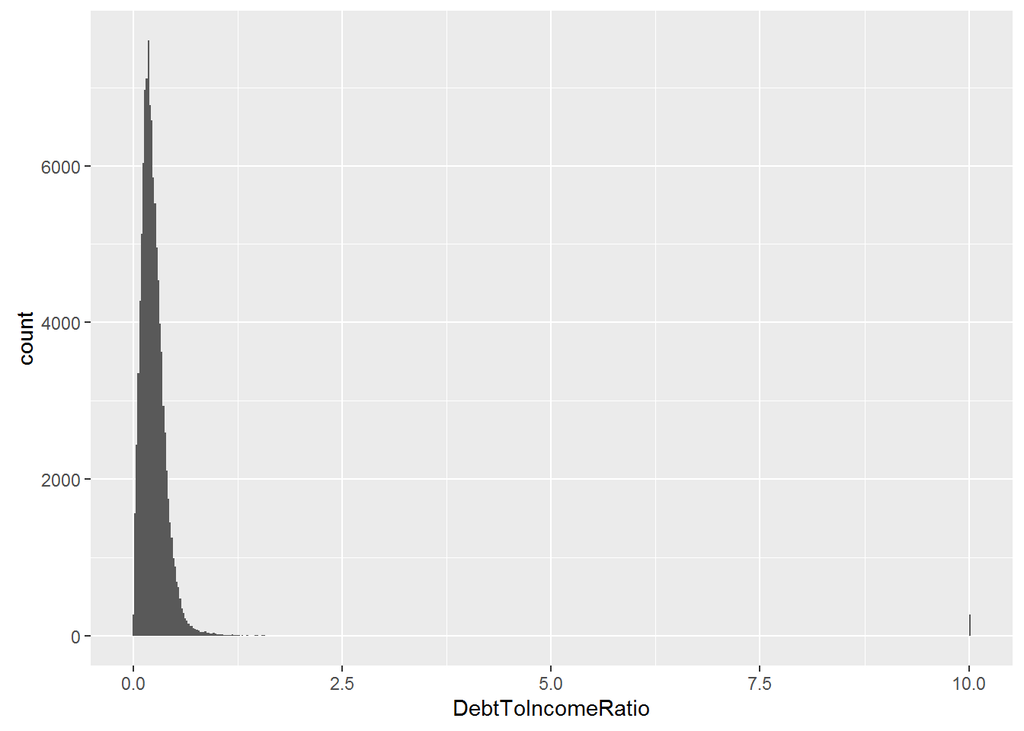

```r
ggplot(aes(x=DebtToIncomeRatio), data=subset(df,!is.na(DebtToIncomeRatio))) +
  geom_histogram(bins=500)
```

There is an outlier at 10.0.

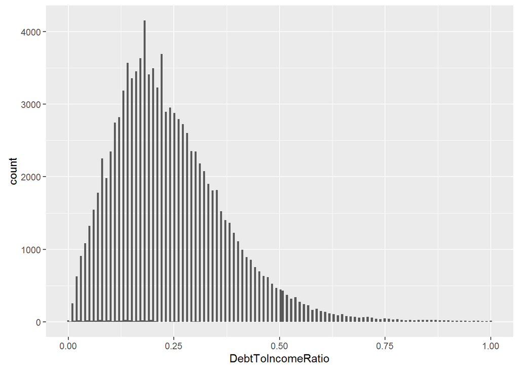

```r
ggplot(aes(x=DebtToIncomeRatio), data=subset(df,!is.na(DebtToIncomeRatio) & DebtToIncomeRatio <= 1)) +
  geom_histogram(bins=200)
```

The graph above shows the Debt to Income Ratio that are less than or equal to 1.

### StatedMonthlyIncome

```r
summary(df$StatedMonthlyIncome)
```

```
##    Min. 1st Qu.  Median    Mean 3rd Qu.    Max.
##       0    3200    4667    5608    6825 1750000
```

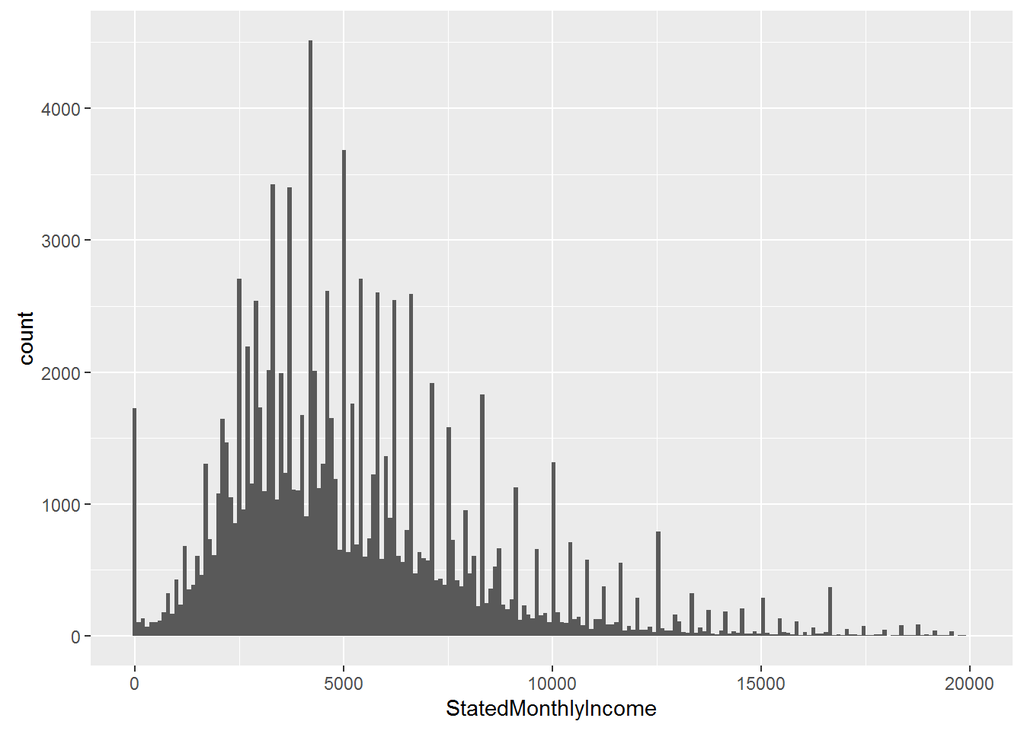

```r
ggplot(aes(x=StatedMonthlyIncome), data=subset(df,StatedMonthlyIncome<20000)) +
  geom_histogram(bins = 200)
```

```r
df %>%
  filter(StatedMonthlyIncome>quantile(df$StatedMonthlyIncome,0.99)) %>%
  summarise(n=n())
```

```
##      n
## 1 1140
```

There are 1140 people with monthly income greater than 20526.67. Most of the peole’s income is around at 4667.

### MonthlyLoanPayment

```r
summary(df$MonthlyLoanPayment)
```

```
##    Min. 1st Qu.  Median    Mean 3rd Qu.    Max.
##     0.0   131.6   217.7   272.5   371.6  2252.0
```

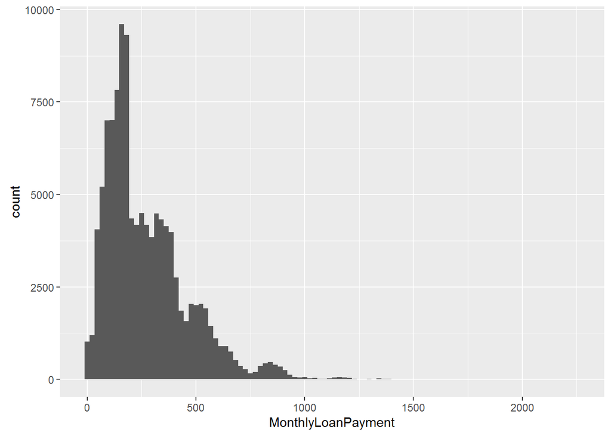

```r
ggplot(aes(x=MonthlyLoanPayment), data=df) +
  geom_histogram(bins=100)
```

### New Variable

```r
df$ratio_monthly_loan_payment <- df$MonthlyLoanPayment / df$StatedMonthlyIncome
summary(df$ratio_monthly_loan_payment)
```

```
##    Min. 1st Qu.  Median    Mean 3rd Qu.    Max.    NA's
## 0.00000 0.02859 0.04962     Inf 0.07865     Inf      15
```

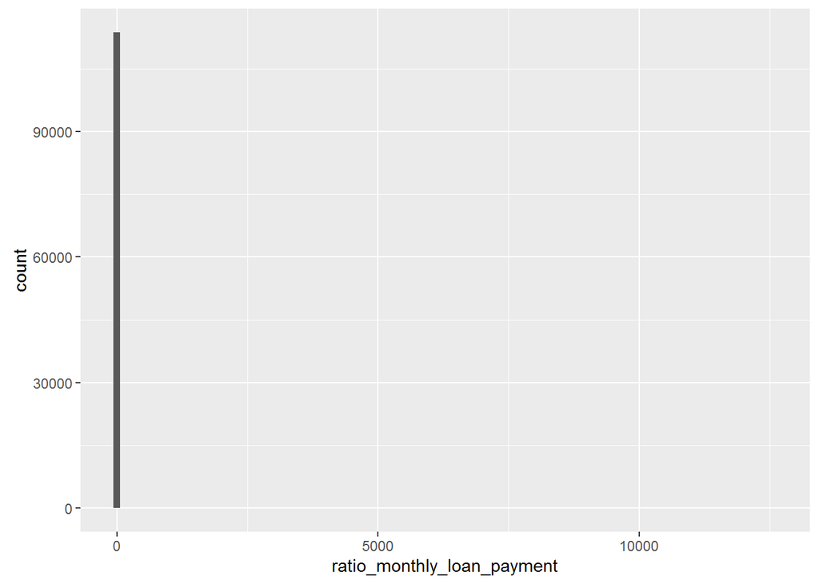

```r
df <- df %>% mutate(ratio_monthly_loan_payment = ifelse(StatedMonthlyIncome==0,0,MonthlyLoanPayment / StatedMonthlyIncome))

ggplot(aes(x=ratio_monthly_loan_payment), data=df) +
  geom_histogram(bins=100)
```

The new variable of the ratio of monthly loan payment to monthly income is created but the graph is not very good since there are many outliers.

```r
df$ratio_monthly_loan_payment.bucket <- cut(df$ratio_monthly_loan_payment, breaks=c(-0.01,.5,12571))

summary(df$ratio_monthly_loan_payment.bucket)
```

```
##    (-0.01,0.5] (0.5,1.26e+04]           NA's
##         113355            581              1
```

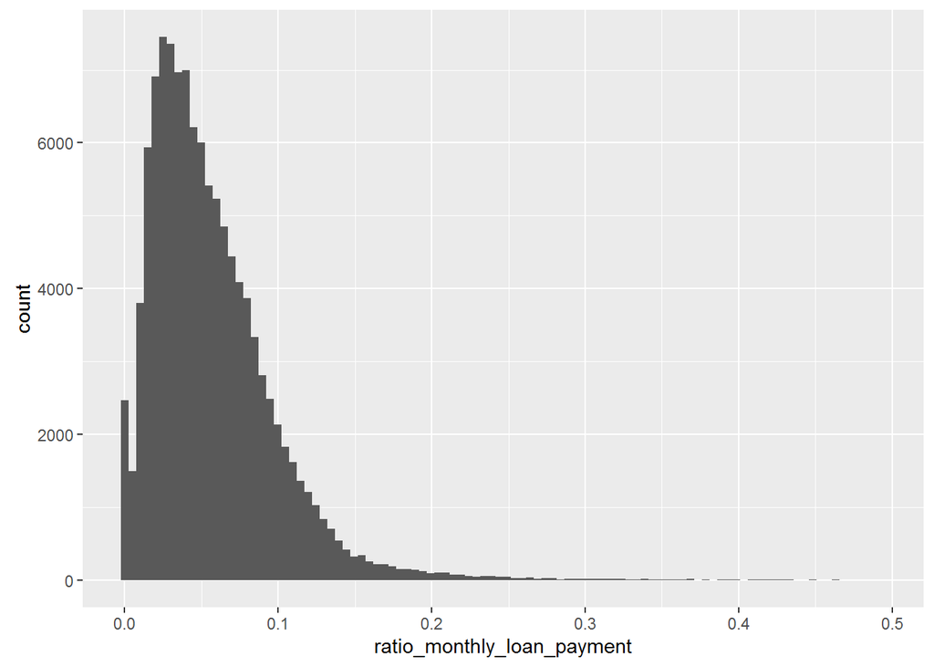

```r
ggplot(aes(x=ratio_monthly_loan_payment), data=subset(df,ratio_monthly_loan_payment<.5)) +
  geom_histogram(bins=100)
```

The above histogram is plotted with subset of the data set where ratio_monthly_loan_payment is less than 0.5. The right skewed graph can be seen clearly.

### Original Loan Amount

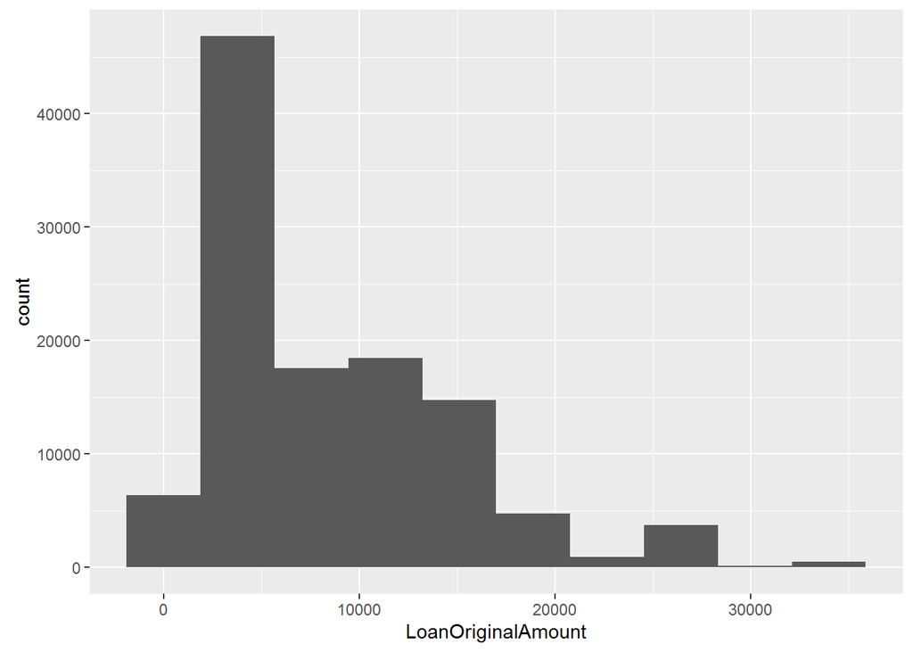

```r
ggplot(aes(x=LoanOriginalAmount), data=df) +
  geom_histogram(bins=10)
```

# Univariate Analysis

### What is the structure of your dataset?

```r
str(df)
```

```
## 'data.frame':    113937 obs. of  86 variables:
##  $ ListingKey                         : Factor w/ 113066 levels "00003546482094282EF90E5",..: 7180 7193 6647 6669 6686 6689 6699 6706 6687 6687 ...
##  $ ListingNumber                      : int  193129 1209647 81716 658116 909464 1074836 750899 768193 1023355 1023355 ...
##  $ ListingCreationDate                : Factor w/ 113064 levels "2005-11-09 20:44:28.847000000",..: 14184 111894 6429 64760 85967 100310 72556 74019 97834 97834 ...
##  $ CreditGrade                        : Factor w/ 9 levels "","A","AA","B",..: 5 1 8 1 1 1 1 1 1 1 ...
##  $ Term                               : Factor w/ 3 levels "12","36","60": 2 2 2 2 2 3 2 2 2 2 ...
##  $ LoanStatus                         : Factor w/ 12 levels "Cancelled","Chargedoff",..: 3 4 3 4 4 4 4 4 4 4 ...
##  $ ClosedDate                         : Factor w/ 2803 levels "","2005-11-25 00:00:00",..: 1138 1 1263 1 1 1 1 1 1 1 ...
##  $ BorrowerAPR                        : num  0.165 0.12 0.283 0.125 0.246 ...
##  $ BorrowerRate                       : num  0.158 0.092 0.275 0.0974 0.2085 ...
##  $ LenderYield                        : num  0.138 0.082 0.24 0.0874 0.1985 ...
##  $ EstimatedEffectiveYield            : num  NA 0.0796 NA 0.0849 0.1832 ...
##  $ EstimatedLoss                      : num  NA 0.0249 NA 0.0249 0.0925 ...
##  $ EstimatedReturn                    : num  NA 0.0547 NA 0.06 0.0907 ...
##  $ ProsperRating..numeric.            : int  NA 6 NA 6 3 5 2 4 7 7 ...
```

[output cut: 72 more lines]

There are 113937 observations and 86 variables. There are a lot of factor variables and below is a list of factor variables I will use for the further analysis.

CreditGrade, Term, LoanStatus, ProsperScore, BorrowerState, Occupation, EmploymentStatus, IncomeRange

### What is/are the main feature(s) of interest in your dataset?

I am interested in finding which variable affects the credit score. And I will find if there is any correlation between income related variables and Loan Status.

### What other features in the dataset do you think will help support your investigation into your feature(s) of interest?

People have different interest rates, monthly income, monthly loan payment, etc. These variables might affect their capabilities of repaying their loans. And depending on their employment status, occupations and credit scores, their loan amount may be different. For instance, I am expecting that people with low credit scores will have higher interest rates.

### Did you create any new variables from existing variables in the dataset?

I created several new variables: BorrowerAPR.bucket, EstimatedReturn.bucket, CreditScoreRangeMid and ratio monthly loan payment. BorrowerAPR.bucket and EstimatedReturn.bucket are divided into intervals so that it can be used as factor variables. CreditScoreRangeMid is the average of CreditScoreRangeLower and CreditScoreRangeUpper. Ratio monthly loan payment is the ratio of monthly loan to monthly income.

### Of the features you investigated, were there any unusual distributions? Did you perform any operations on the data to tidy, adjust, or change the form of the data? If so, why did you do this?

After plotting many histograms from various variables, a consistent pattern can be found in the histograms. Some of them have an unusually high peak at the right of the median. I cutted such variables into distinct intervals so that I can use them with multivariable analysis.

# Bivariate Plots Section

```
##  [1] "Term"                       "LoanStatus"
##  [3] "BorrowerRate"               "EstimatedReturn"
##  [5] "ProsperScore"               "TotalCreditLinespast7years"
##  [7] "StatedMonthlyIncome"        "LoanOriginalAmount"
##  [9] "MonthlyLoanPayment"         "CreditScoreRangeMid"
## [11] "ratio_monthly_loan_payment"
```

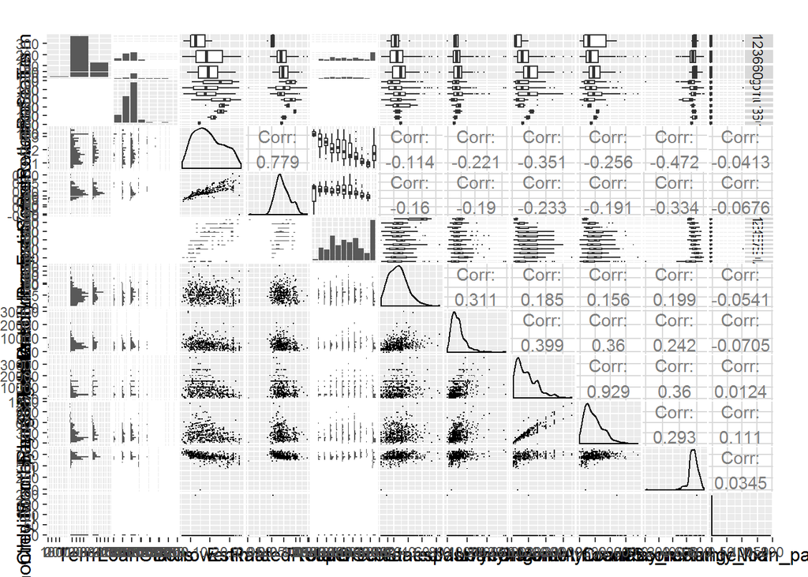

```
##      Min.   1st Qu.    Median      Mean   3rd Qu.      Max.
##     0.000     0.028     0.048     8.058     0.077 12570.000
```

According to the matrix, BorrowerRate and Estimated return are positively correlated. And there is interesting thing going on with ProsperScore and BorrowerRate. There is strong positive correlation between LoanOriginalAmount and Monthly Loan Payment.

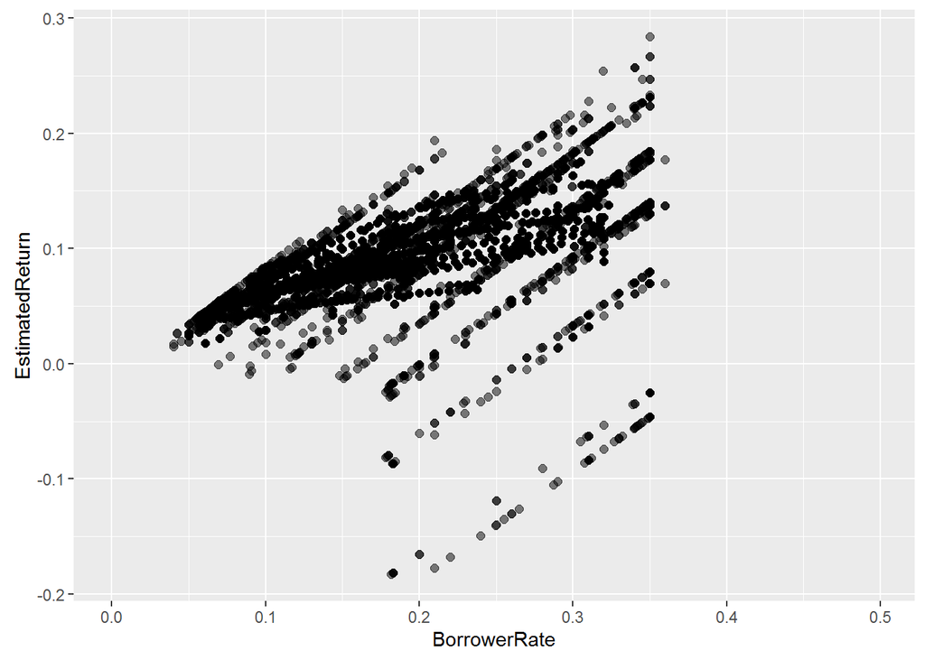

```r
ggplot(aes(x=BorrowerRate,y=EstimatedReturn),data=df) +
  geom_point(size=2, alpha=0.5)
```

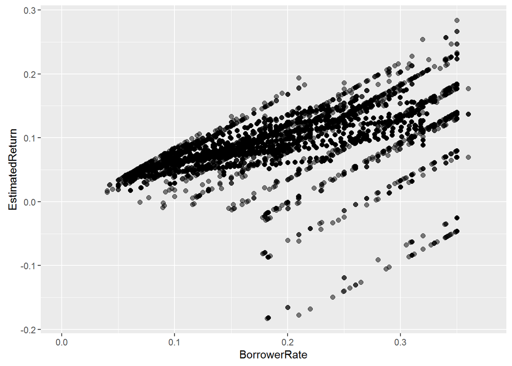

```r
ggplot(aes(x=BorrowerRate,y=EstimatedReturn),
       data=subset(df,df$BorrowerRate<.4 & df$BorrowerRate>0)) +
  geom_point(size=2, alpha=0.5)
```

Overal plot is showing positive correlation but the plot actually shows the multiple linear lines with the same slope.

```r
f <-lm(formula = EstimatedReturn ~ BorrowerRate, data = subset(df, BorrowerRate <=
  quantile(df$BorrowerRate, 0.999)))

summary(f)
```

```
##
## Call:
## lm(formula = EstimatedReturn ~ BorrowerRate, data = subset(df,
##     BorrowerRate <= quantile(df$BorrowerRate, 0.999)))
##
## Residuals:
##       Min        1Q    Median        3Q       Max
## -0.278026 -0.008661 -0.002077  0.008565  0.136335
##
## Coefficients:
##               Estimate Std. Error t value Pr(>|t|)
## (Intercept)  0.0307679  0.0001689   182.2   <2e-16 ***
## BorrowerRate 0.3331341  0.0008051   413.8   <2e-16 ***
## ---
## Signif. codes:  0 '***' 0.001 '**' 0.01 '*' 0.05 '.' 0.1 ' ' 1
##
## Residual standard error: 0.0175 on 84846 degrees of freedom
##   (29039 observations deleted due to missingness)
## Multiple R-squared:  0.6686, Adjusted R-squared:  0.6686
## F-statistic: 1.712e+05 on 1 and 84846 DF,  p-value: < 2.2e-16
```

```r
cor.test(df$EstimatedReturn,df$BorrowerRate)
```

```
##
##  Pearson's product-moment correlation
##
## data:  df$EstimatedReturn and df$BorrowerRate
## t = 413.73, df = 84851, p-value < 2.2e-16
## alternative hypothesis: true correlation is not equal to 0
## 95 percent confidence interval:
##  0.8154276 0.8198876
## sample estimates:
##       cor
## 0.8176699
```

R^2 is 0.6686 and correlation is 0.8177. More analysis is required to explain the obvious linear patterns in a graph.

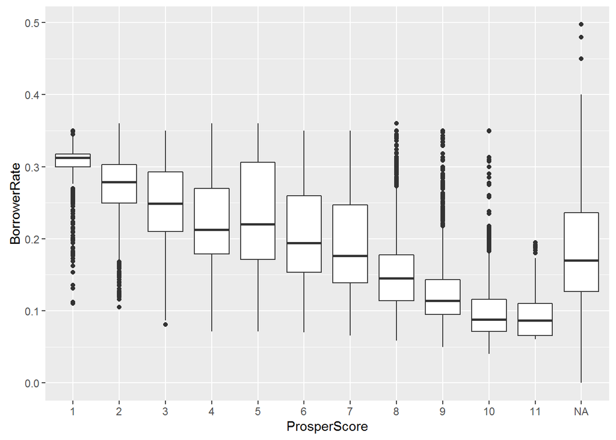

```r
ggplot(aes(x=ProsperScore,y=BorrowerRate), data=df) +
  geom_boxplot()
```

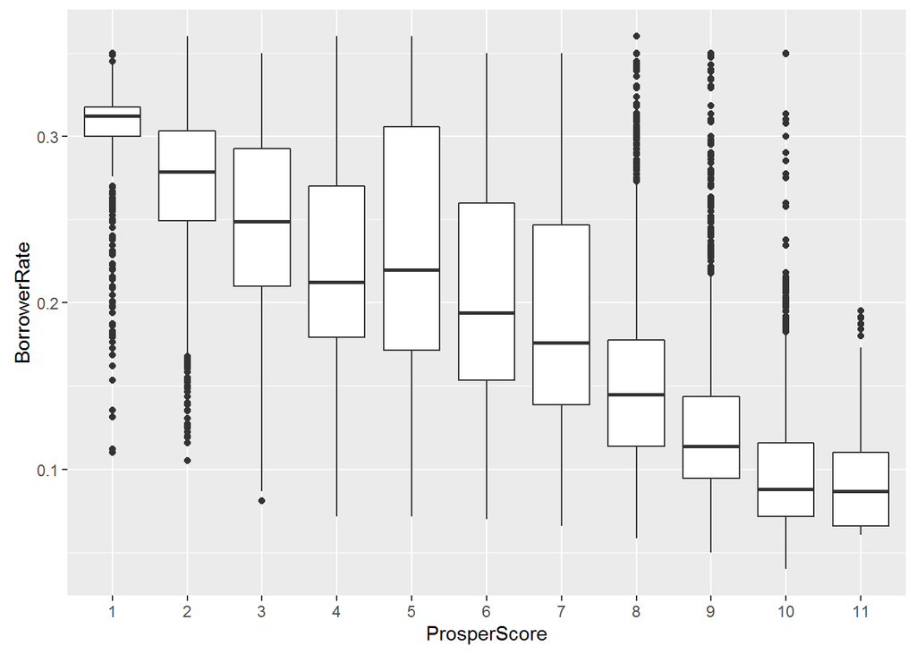

```r
ggplot(aes(x=ProsperScore,y=BorrowerRate), data=subset(df,!is.na(ProsperScore))) +
  geom_boxplot()
```

NA values in ProsperScore can be ignored. And a clear pattern can be observed in this box plot. As score gets higher, borrower rate gets lower.

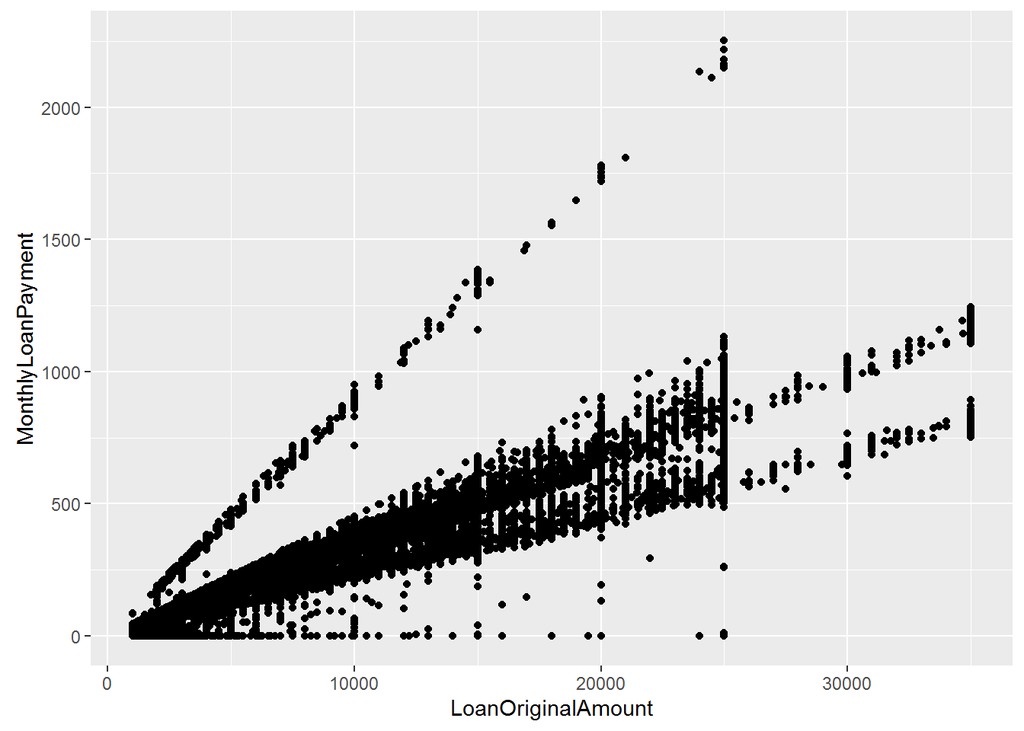

```r
ggplot(aes(x=LoanOriginalAmount,y=MonthlyLoanPayment), data=df) +
  geom_point()
```

Clear linear pattern can be observed from the graph. Interesting thing is that 3 distinct linear lines can be seen.

```r
ff <- lm(MonthlyLoanPayment ~ LoanOriginalAmount, data=df)

summary(ff)
```

```
##
## Call:
## lm(formula = MonthlyLoanPayment ~ LoanOriginalAmount, data = df)
##
## Residuals:
##     Min      1Q  Median      3Q     Max
## -751.60  -23.45   -1.04   25.94 1499.91
##
## Coefficients:
##                     Estimate Std. Error t value Pr(>|t|)
## (Intercept)        3.275e+01  3.452e-01    94.9   <2e-16 ***
## LoanOriginalAmount 2.875e-02  3.313e-05   867.8   <2e-16 ***
## ---
## Signif. codes:  0 '***' 0.001 '**' 0.01 '*' 0.05 '.' 0.1 ' ' 1
##
## Residual standard error: 69.85 on 113935 degrees of freedom
## Multiple R-squared:  0.8686, Adjusted R-squared:  0.8686
## F-statistic: 7.531e+05 on 1 and 113935 DF,  p-value: < 2.2e-16
```

```r
cor.test(df$MonthlyLoanPayment,df$LoanOriginalAmount)
```

[output not shown]

As a result, these two variables have very high values of R^2 and correlation. This is reasonable because those with more loan amount have to pay more.